# 경제자료분석과 예측 - #02 통계적 예측

경제학과 김현학 교수

2025년 2학기

# 1 수업 목표와 로드맵

- **예측의 관점**: 포인트 예측(point), 구간/분포 예측(density)의 차이와 목적 이해
- **평가 지표**: RMSE/MAE/MAPE/MASE, Pinball loss, Calibration 등 장단점 비교
- **검증 전략**: 홀드아웃, 확장(Expanding) 창, 롤링(Rolling) 창, `tsCV()` 기반 시계열 교차검증
- **기준 모형(Benchmark)**: 평균, *naïve*, 계절 *naïve*
- **모형군**: ETS(지수평활), ARIMA, STL+ETS, 단순 조합(average)
- **모형 비교**: Diebold–Mariano 검정, 현실적 유의성(경제적 유의성) 논의
- **실습 데이터**: `AirPassengers`(월별 항공여객), `WWWusage`(웹 사용량) 등 내장 데이터

# 2 패키지 불러오기

```r
# ---- 분석에 필요한 패키지 로드 ----
library(forecast)   # 예측 모형(ETS/ARIMA), 정확도(accuracy), tsCV, dm.test 등
```

```r
library(tseries)    # 보조 검정(필요 시)
library(ggplot2)   # 시각화
library(fpp3)    # Hyndman 데이터셋(선택) - 수업 환경에 설치되어 있으면 사용
```

# 3 데이터 소개와 기초 탐색

본 장은 R 내장 시계열로 예측의 전형적 흐름을 연습한다.

```r
# ---- 예시 데이터: AirPassengers (월별, 1949-1960) ----
ap <- AirPassengers
start(ap); end(ap); frequency(ap)
```

```
## [1] 1949    1
```

```
## [1] 1960   12
```

```
## [1] 12
```

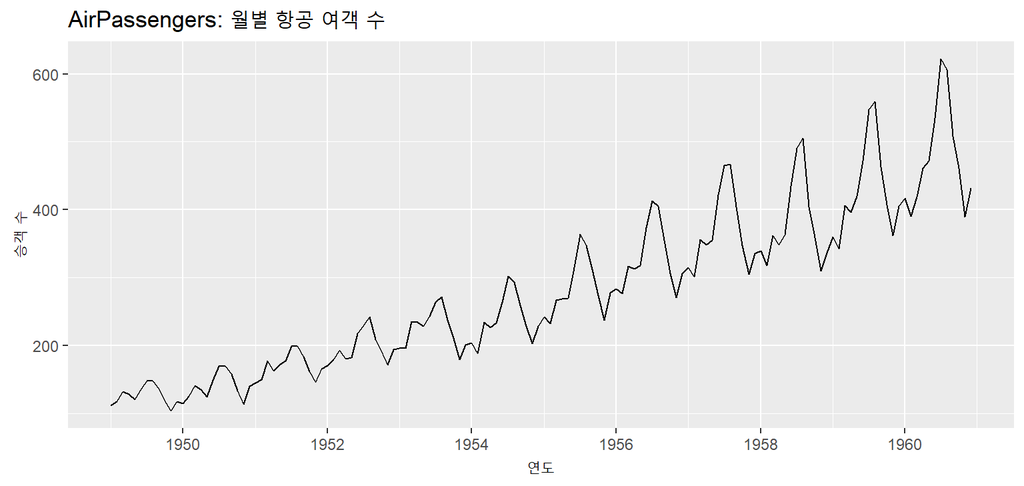

```r
autoplot(ap) +
  ggtitle("AirPassengers: 월별 항공 여객 수") +
  xlab("연도") + ylab("승객 수")
```

**관찰 포인트**  
- **뚜렷한 추세**(상승)와 **강한 계절성**이 존재  
- 분산이 시간에 따라 커지는 **이분산성(variance 증가)** → 로그 변환 고려

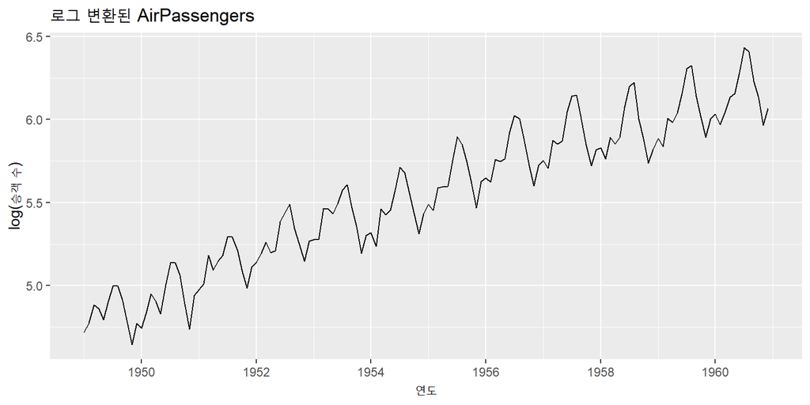

```r
# ---- 로그 변환으로 분산 안정화 ----
lap <- log(ap)
autoplot(lap) + ggtitle("로그 변환된 AirPassengers") + xlab("연도") + ylab("log(승객 수)")
```

# 4 예측의 관점: 포인트 vs. 구간/분포

- **포인트 예측**: 미래 시점의 **대표값(평균/중앙값 등)** 추정
- **구간/분포 예측**: 예측의 **불확실성**까지 표현(예: 80%/95% 예측구간, 전체 분포)
- 정책·리스크 관리에서는 **분위수/밀도 예측**이 더 중요할 수 있음

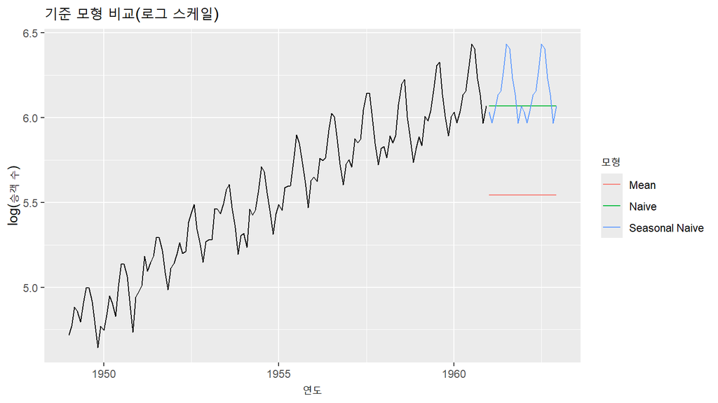

```r
# ---- 기준 모형(benchmark) 예측 ----
fit_mean  <- meanf(lap, h = 24)      # 평균모형
fit_rw    <- rwf(lap, h = 24)        # 랜덤워크(naive)
fit_snaive<- snaive(lap, h = 24)     # 계절 naïve

autoplot(lap) +
  autolayer(fit_mean$mean, series = "Mean") +
  autolayer(fit_rw$mean,   series = "Naive") +
  autolayer(fit_snaive$mean, series = "Seasonal Naive") +
  ggtitle("기준 모형 비교(로그 스케일)") + xlab("연도") + ylab("log(승객 수)") +
  guides(colour = guide_legend(title = "모형"))
```

> **좋은 실무 습관**: 우선 간단한 기준모형을 설정하고, 고급 모형은 **기준보다 얼마나 개선되는지**로 평가한다.

# 5 모형 적합: ETS / ARIMA / STL+ETS

```r
# ---- ETS (지수평활 상태공간) ----
fit_ets   <- ets(lap)          # 자동 모형 선택
# ---- ARIMA ----
fit_arima <- auto.arima(lap, stepwise = FALSE, approximation = FALSE)
# ---- STL+ETS ----
fit_stl   <- stlm(lap, s.window = "periodic", method = "ets")

fit_ets
```

```
## ETS(M,A,M)
##
## Call:
## ets(y = lap)
##
##   Smoothing parameters:
##     alpha = 0.5871
##     beta  = 1e-04
##     gamma = 1e-04
##
##   Initial states:
##     l = 4.8055
##     b = 0.0091
##     s = 0.9814 0.96 0.9866 1.0116 1.0376 1.0379
##            1.02 0.9985 0.9986 1.004 0.9804 0.9833
##
##   sigma:  0.0069
##
##       AIC      AICc       BIC
## -208.3403 -203.4832 -157.8535
```

```r
fit_arima
```

```
## Series: lap
## ARIMA(0,1,1)(0,1,1)[12]
##
## Coefficients:
##           ma1     sma1
##       -0.4018  -0.5569
## s.e.   0.0896   0.0731
##
## sigma^2 = 0.001371:  log likelihood = 244.7
## AIC=-483.4   AICc=-483.21   BIC=-474.77
```

```r
fit_stl$model
```

```
## ETS(A,A,N)
##
## Call:
## ets(y = x, model = etsmodel, allow.multiplicative.trend = allow.multiplicative.trend)
##
##   Smoothing parameters:
##     alpha = 0.6889
##     beta  = 1e-04
##
##   Initial states:
##     l = 4.8686
##     b = 0.0092
##
##   sigma:  0.0367
##
##       AIC      AICc       BIC
## -230.4054 -229.9706 -215.5563
```

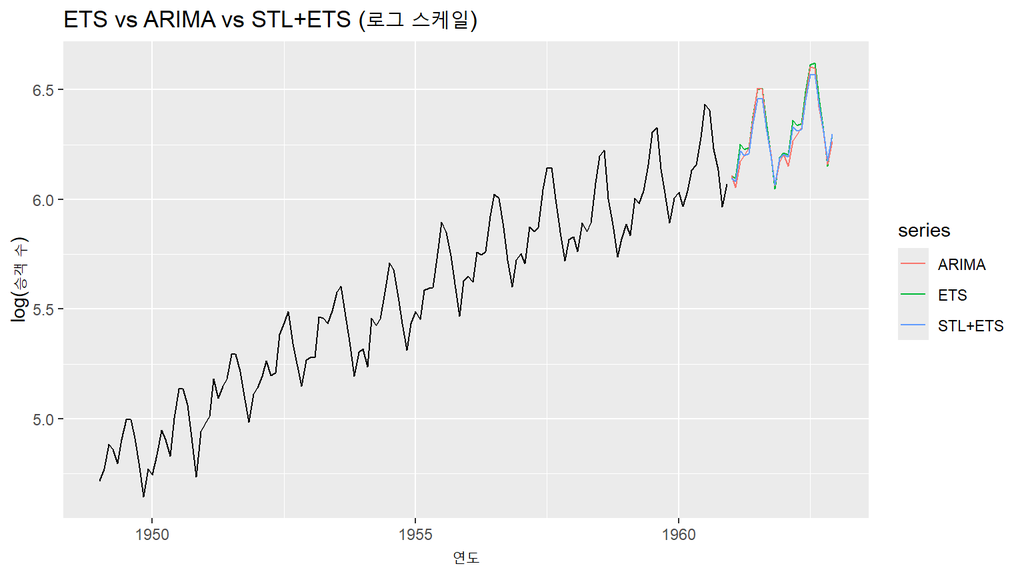

```r
# ---- 24개월 예측 ----
h <- 24
fc_ets   <- forecast(fit_ets,   h = h)
fc_arima <- forecast(fit_arima, h = h)
fc_stl   <- forecast(fit_stl,   h = h)

autoplot(lap) +
  autolayer(fc_ets$mean,   series = "ETS") +
  autolayer(fc_arima$mean, series = "ARIMA") +
  autolayer(fc_stl$mean,   series = "STL+ETS") +
  ggtitle("ETS vs ARIMA vs STL+ETS (로그 스케일)") + xlab("연도") + ylab("log(승객 수)")
```

> **이론 메모**  
> - **ETS**: 오차(Error)–추세(Trend)–계절(Seasonality) 조합(E, A, M 등) 자동 탐색  
> - **ARIMA**: 차분으로 정상화 후 ARMA 성분을 적합. 비계절/계절 성분(`seasonal` 인수) 모두 처리 가능  
> - **STL+ETS**: 계절 성분을 STL로 분해 후 비계절 부분을 ETS로 예측 → 강한 계절성일 때 견고

# 6 평가 지표: RMSE/MAE/MAPE/MASE & 핀볼 손실

- **RMSE**: 큰 오차에 가중(제곱), 외란이 정규에 가까울 때 유리
- **MAE**: 이상치에 비교적 강건, 중앙값에 대응
- **MAPE**: 0 근처 값에 불안정(분모 문제), 스케일 불변 장점
- **MASE**: *naïve* 대비 상대 오차 → **서로 다른 시계열 간 비교 가능**
- **Pinball loss**: 분위수 예측 평가(예: 0.1, 0.5, 0.9 분위수)

```r
# ---- 홀드아웃: 마지막 24개월을 테스트로 분리 ----
h <- 24
n <- length(lap)
train <- window(lap, end = c(1960 - ceiling((h-1)/12), 12 - ((h-1) %% 12)))

# 간편 대안: window(lap, end=c(1958,12))  # 1959-1960을 테스트로
train <- window(lap, end=c(1958,12))
test  <- window(lap, start=c(1959,1))

# 훈련에서 재적합 후 테스트 구간 예측
fc_ets_te   <- forecast(ets(train),   h = length(test))
fc_arima_te <- forecast(auto.arima(train, stepwise=FALSE, approximation=FALSE),
                        h = length(test))
fc_snaive_te<- forecast(snaive(train), h = length(test))

# 정확도 비교 (원래 스케일로 보고 싶다면 exp() 변환 고려)
acc_ets   <- accuracy(fc_ets_te,   test)
acc_arima <- accuracy(fc_arima_te, test)
acc_snaive<- accuracy(fc_snaive_te, test)

rbind(ETS=acc_ets[2, c("RMSE","MAE","MAPE","MASE")],
      ARIMA=acc_arima[2, c("RMSE","MAE","MAPE","MASE")],
      SNAIVE=acc_snaive[2, c("RMSE","MAE","MAPE","MASE")])
```

```
##              RMSE        MAE     MAPE      MASE
## ETS    0.04250956 0.03579274 0.586529 0.2907800
## ARIMA  0.09593236 0.08959921 1.463477 0.7279033
## SNAIVE 0.18212295 0.17070905 2.791918 1.3868392
```

> **실무 팁**: 로그 스케일로 학습했다면 예측을 `exp()`로 되돌릴 때 **Jensen 부등식**에 의한 바이어스 보정(예: `exp(pred + s2/2)`)을 검토하자.

# 7 시계열 교차검증(tsCV)와 롤링/확장 창

```r
# ---- tsCV: 한 시점씩 앞 예측 오차 축적 ----
# 예시: ARIMA 1-step ahead 오류
e_arima <- tsCV(lap, forecastfunction = function(y, h) {
  forecast(auto.arima(y, stepwise=TRUE, approximation=TRUE), h=h)
}, h = 1)

e_snaive <- tsCV(lap, function(y, h) forecast(snaive(y), h=h), h=1)

# 평균제곱오차 비교(NA 제외)
rmse_arima  <- sqrt(mean(e_arima^2,  na.rm=TRUE))
rmse_snaive <- sqrt(mean(e_snaive^2, na.rm=TRUE))
c(RMSE_ARIMA = rmse_arima, RMSE_SNAIVE = rmse_snaive)
```

```
##  RMSE_ARIMA RMSE_SNAIVE
##  0.06328291  0.13464199
```

> **검증 전략**  
> - **확장 창(Expanding)**: 시작은 짧게, 시간이 지날수록 훈련 기간 확장  
> - **롤링 창(Rolling)**: 고정된 창 길이를 유지하며 순차적으로 이동  
> - **tsCV**는 체계적으로 한 단계 또는 여러 단계 앞 예측오차를 모아 비교

# 8 모형 비교의 통계적 검정: Diebold–Mariano

동일한 타깃, 동일한 테스트 구간에서 두 모형의 예측오차를 비교할 때 사용.

```r
# ---- 동일 테스트 구간에서 ETS vs ARIMA 비교 ----
e1 <- test - fc_ets_te$mean
e2 <- test - fc_arima_te$mean

# 손실함수: 제곱오차 (power = 2), h=1일 때 유효
forecast::dm.test(e1, e2, h = 1, power = 2)
```

```
##
##  Diebold-Mariano Test
##
## data:  e1e2
## DM = -5.3316, Forecast horizon = 1, Loss function power = 2, p-value =
## 2.057e-05
## alternative hypothesis: two.sided
```

> **해석**: p-value < 0.05 → 두 모형의 예측성능(평균 손실)이 통계적으로 유의하게 다름.  
> **주의**: 다단계 예측(h>1)에서는 표준 DM 절차의 가정 위반 가능성에 주의.

# 9 예측구간과 밀도 예측, 보정(calibration)

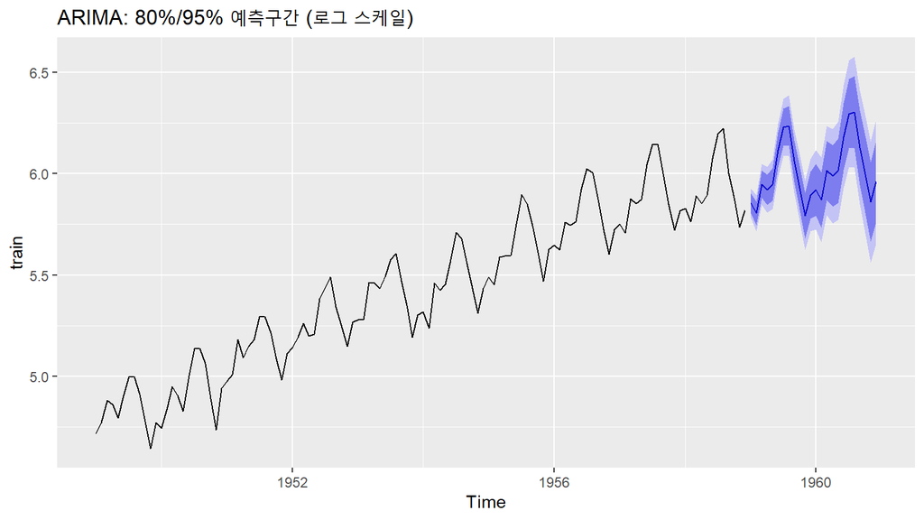

```r
# ---- 80%/95% 예측구간 시각화 ----
autoplot(fc_arima_te) + ggtitle("ARIMA: 80%/95% 예측구간 (로그 스케일)")
```

```r
# ---- 간단한 구간 적중률 체크(실제 로그 스케일 기준) ----
inside95 <- mean(test >= fc_arima_te$lower[,"95%"] & test <= fc_arima_te$upper[,"95%"])
inside80 <- mean(test >= fc_arima_te$lower[,"80%"] & test <= fc_arima_te$upper[,"80%"])
c(Coverage80 = inside80, Coverage95 = inside95)
```

```
## Coverage80 Coverage95
##  0.9583333  1.0000000
```

> **보정(Calibration)**: 목표 신뢰수준(예: 95%) 대비 실제 포함비율이 지속적으로 낮다면 **과소/과대 신뢰** 문제를 의심하고 폭 조정·모형 변경을 고려.

# 10 조합 예측(Ensemble)과 실무 팁

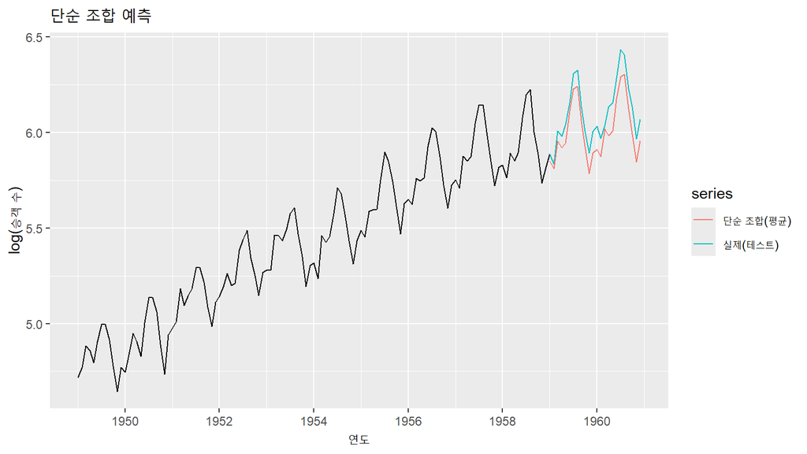

```r
# ---- 단순 평균 조합 (수정: 지표 계산 안전화) ----
fc_mean <- (fc_ets_te$mean + fc_arima_te$mean + fc_snaive_te$mean)/3

autoplot(lap) +
  autolayer(test, series="실제(테스트)") +
  autolayer(fc_mean, series="단순 조합(평균)") +
  ggtitle("단순 조합 예측") + xlab("연도") + ylab("log(승객 수)")
```

```r
# 정확도 계산(테스트 구간 기준)
fc_mean_ts <- ts(as.numeric(fc_mean), start = start(test), frequency = frequency(test))

# 1) 기본 지표
RMSE <- sqrt(mean((test - fc_mean_ts)^2, na.rm=TRUE))
MAE  <- mean(abs(test - fc_mean_ts), na.rm=TRUE)
MAPE <- mean(abs((test - fc_mean_ts)/test), na.rm=TRUE) * 100

# 2) MASE (훈련 구간에 대한 계절 naive 기준 스케일)
m <- frequency(train)
if (m > 1) {
  denom <- mean(abs(train[(m+1):length(train)] - train[1:(length(train)-m)]), na.rm=TRUE)
} else {
  denom <- mean(abs(diff(train)), na.rm=TRUE)
}
MASE <- MAE / denom

acc_comb <- data.frame(RMSE=RMSE, MAE=MAE, MAPE=MAPE, MASE=MASE)
acc_comb
```

| RMSE | MAE | MAPE | MASE |
| --- | --- | --- | --- |
| 0.1002548 | 0.09301833 | 1.519389 | 0.7556803 |

# 11 비계절 예시(WWWusage)와 자동화

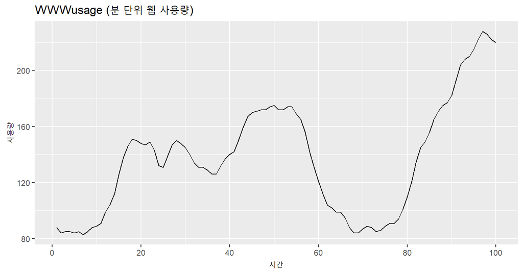

```r
w <- WWWusage
autoplot(w) + ggtitle("WWWusage (분 단위 웹 사용량)") + xlab("시간") + ylab("사용량")
```

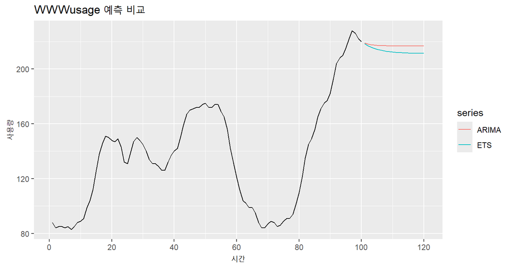

```r
fw_arima <- forecast(auto.arima(w), h = 20)
fw_ets   <- forecast(ets(w), h = 20)

autoplot(w) + autolayer(fw_arima$mean, series="ARIMA") + autolayer(fw_ets$mean, series="ETS") +
  ggtitle("WWWusage 예측 비교") + xlab("시간") + ylab("사용량")
```

# 12 흔한 함정과 체크리스트

- **데이터 누수(leakage)**: 미래 정보가 특징/모형에 유입되지 않도록 분할과 전처리 순서 주의
- **MAPE의 문제**: 0 근처 값, 음수 값에서 불안정 → MAE/MASE 병행
- **스케일 문제**: 로그/Box–Cox 변환 시 역변환 바이어스 보정 고려
- **벤치마크**: *naïve/seasonal naïve*를 항상 포함해 상대 성능을 확인
- **경제적 유의성**: 통계적 유의성 외에 **정책/거래비용/위험회피** 등의 맥락적 의미 평가

# 13 용어 정리

- **예측 대상**: 확률변수 $y_t$.
- **예측 분포**: $\mathcal{I}$를 모든 관측치(정보)라고 하면, $y_t \mid \mathcal{I}$는 “정보 $\mathcal{I}$가 주어졌을 때의 확률변수 $y_t$”를 의미한다.
- **점 예측(point forecast)**: $y_t \mid \mathcal{I}$의 **평균(또는 중앙값)**.
- **예측 분산(forecast variance)**: $\mathrm{Var}\!\left[y_t \mid \mathcal{I}\right]$.
- **예측구간(구간 예측, prediction interval)**: 높은 확률로 $y_t$가 포함될 값의 범위(예: $(1-\alpha)\times 100\%$ 예측구간).
- **시계열 표기**: $y_{t\mid t-1} = y_t \mid \{y_1, y_2, \dots, y_{t-1}\}$.
- **$h$-단계 앞 예측**: $\hat{y}_{T+h\mid T} = \mathbb{E}\!\left[\,y_{T+h} \mid y_1,\dots,y_T\,\right]$ (시점 $T$까지의 모든 관측을 이용한 $h$-스텝 예측).

# 14 과제

1. `AirPassengers`를 대상으로 **STL+ETS**와 **ARIMA**의 `tsCV` 기반 1-step RMSE를 비교하고, **DM 검정**으로 유의한 차이가 있는지 확인하라.
2. `Water` 또는 `WWWusage` 자료로 **홀드아웃(마지막 20%)**을 설정해 ETS/ARIMA/조합 모형의 RMSE·MAE·MASE를 비교하라.
3. `snaive()`를 벤치마크로 하여 **MASE < 1**을 달성하는 모형을 찾아라. 파라미터/전처리 선택을 서술하라.